# RD-and-Clustering-Decathlon_project_E.Humbert

```python
### RD & Clustering - PROJECT 2 : Decathlon Dataset ###
```

```python
# Installing packages
import pandas as pd
import numpy as np
import matplotlib.pyplot as plt
import seaborn as sns
from sklearn.decomposition import PCA
from sklearn.preprocessing import StandardScaler
from mpl_toolkits.mplot3d import Axes3D
import plotly.express as px
from scipy.stats import pearsonr
from sklearn.pipeline import make_pipeline
from sklearn.cluster import KMeans
from sklearn.metrics import silhouette_samples, silhouette_score
from matplotlib.colors import Normalize
import matplotlib.cm as cm
from scipy.cluster.hierarchy import dendrogram, linkage
```

```python
# Loading Decathlon dataset
decathlon_df= pd.read_csv("C://Users//emmhu//OneDrive//Documents//E-LEARNING//DU DATA ANALYST//3_RD & Clustering//Données//Datasets//decathlon.csv", sep= ";", encoding="utf-8")

decathlon_df.head()
```

|  | Unnamed: 0 | 100m | Longueur | Poids | Hauteur | 400m | 110m H | Disque | Perche | Javelot | 1500m | Classement | Points | Competition |
| --- | --- | --- | --- | --- | --- | --- | --- | --- | --- | --- | --- | --- | --- | --- |
| 0 | Sebrle | 10.85 | 7.84 | 16.36 | 2.12 | 48.36 | 14.05 | 48.72 | 5.0 | 70.52 | 280.01 | 1 | 8893 | JO |
| 1 | Clay | 10.44 | 7.96 | 15.23 | 2.06 | 49.19 | 14.13 | 50.11 | 4.9 | 69.71 | 282.00 | 2 | 8820 | JO |
| 2 | Karpov | 10.50 | 7.81 | 15.93 | 2.09 | 46.81 | 13.97 | 51.65 | 4.6 | 55.54 | 278.11 | 3 | 8725 | JO |
| 3 | Macey | 10.89 | 7.47 | 15.73 | 2.15 | 48.97 | 14.56 | 48.34 | 4.4 | 58.46 | 265.42 | 4 | 8414 | JO |
| 4 | Warners | 10.62 | 7.74 | 14.48 | 1.97 | 47.97 | 14.01 | 43.73 | 4.9 | 55.39 | 278.05 | 5 | 8343 | JO |

```python
# Renaming the "unnamed:0" column
decathlon_df.rename(columns={'Unnamed: 0': 'Athlete'}, inplace=True)
decathlon_df.head()
```

|  | Athlete | 100m | Longueur | Poids | Hauteur | 400m | 110m H | Disque | Perche | Javelot | 1500m | Classement | Points | Competition |
| --- | --- | --- | --- | --- | --- | --- | --- | --- | --- | --- | --- | --- | --- | --- |
| 0 | Sebrle | 10.85 | 7.84 | 16.36 | 2.12 | 48.36 | 14.05 | 48.72 | 5.0 | 70.52 | 280.01 | 1 | 8893 | JO |
| 1 | Clay | 10.44 | 7.96 | 15.23 | 2.06 | 49.19 | 14.13 | 50.11 | 4.9 | 69.71 | 282.00 | 2 | 8820 | JO |
| 2 | Karpov | 10.50 | 7.81 | 15.93 | 2.09 | 46.81 | 13.97 | 51.65 | 4.6 | 55.54 | 278.11 | 3 | 8725 | JO |
| 3 | Macey | 10.89 | 7.47 | 15.73 | 2.15 | 48.97 | 14.56 | 48.34 | 4.4 | 58.46 | 265.42 | 4 | 8414 | JO |
| 4 | Warners | 10.62 | 7.74 | 14.48 | 1.97 | 47.97 | 14.01 | 43.73 | 4.9 | 55.39 | 278.05 | 5 | 8343 | JO |

```python
# Inspecting the dataset
print(decathlon_df.shape)
print(decathlon_df.describe())
print(decathlon_df.info())
```

```
(41, 14)
            100m   Longueur      Poids    Hauteur       400m     110m H  \
count  41.000000  41.000000  41.000000  41.000000  41.000000  41.000000
mean   10.998049   7.260000  14.477073   1.976829  49.616341  14.605854
std     0.263023   0.316402   0.824428   0.088951   1.153451   0.471789
min    10.440000   6.610000  12.680000   1.850000  46.810000  13.970000
25%    10.850000   7.030000  13.880000   1.920000  48.930000  14.210000
50%    10.980000   7.300000  14.570000   1.950000  49.400000  14.480000
75%    11.140000   7.480000  14.970000   2.040000  50.300000  14.980000
max    11.640000   7.960000  16.360000   2.150000  53.200000  15.670000

          Disque     Perche    Javelot       1500m  Classement       Points
count  41.000000  41.000000  41.000000   41.000000   41.000000    41.000000
mean   44.325610   4.762439  58.316585  279.024878   12.121951  8005.365854
std     3.377845   0.278000   4.826820   11.673247    7.918949   342.385145
min    37.920000   4.200000  50.310000  262.100000    1.000000  7313.000000
25%    41.900000   4.500000  55.270000  271.020000    6.000000  7802.000000
50%    44.410000   4.800000  58.360000  278.050000   11.000000  8021.000000
75%    46.070000   4.920000  60.890000  285.100000   18.000000  8122.000000
max    51.650000   5.400000  70.520000  317.000000   28.000000  8893.000000
<class 'pandas.core.frame.DataFrame'>
RangeIndex: 41 entries, 0 to 40
Data columns (total 14 columns):
 #   Column       Non-Null Count  Dtype
---  ------       --------------  -----
 0   Athlete      41 non-null     object
 1   100m         41 non-null     float64
 2   Longueur     41 non-null     float64
 3   Poids        41 non-null     float64
 4   Hauteur      41 non-null     float64
 5   400m         41 non-null     float64
 6   110m H       41 non-null     float64
 7   Disque       41 non-null     float64
 8   Perche       41 non-null     float64
 9   Javelot      41 non-null     float64
 10  1500m        41 non-null     float64
 11  Classement   41 non-null     int64
 12  Points       41 non-null     int64
 13  Competition  41 non-null     object
dtypes: float64(10), int64(2), object(2)
memory usage: 4.6+ KB
None
```

```python
#Checking for missing values
missing_values= decathlon_df.isnull()
missing_values_sum= missing_values.sum()
missing_values_sum
```

```
Athlete        0
100m           0
Longueur       0
Poids          0
Hauteur        0
400m           0
110m H         0
Disque         0
Perche         0
Javelot        0
1500m          0
Classement     0
Points         0
Competition    0
dtype: int64
```

```python
# Display the column names
print(decathlon_df.columns)
```

```
Index(['Athlete', '100m', 'Longueur', 'Poids', 'Hauteur', '400m', '110m H',
       'Disque', 'Perche', 'Javelot', '1500m', 'Classement', 'Points',
       'Competition'],
      dtype='object')
```

```python
# 1. Mobilisez les données du jeu de données sur le décathlon, effectuez quelques analyses de réduction de dimensionnalité par ACP, et produisez un cercle
 # des corrélations

 # 1. Mobilize data from the decathlon dataset, perform some dimensionality reduction analysis using PCA, and produce a circle of
 # of correlations
```

```python
# Select only features (numeric values for events) for PCA
features2 = ["100m", "Longueur", "Poids", "Hauteur", "400m", "110m H", "Disque", "Perche", "Javelot", "1500m"]
X = decathlon_df[features2]

# # Standardizing features (centring and reducing)
scaler = StandardScaler()
X_scaled = scaler.fit_transform(X)
```

```python
# Calculate the correlation matrix of the features
correlation_matrix2 = np.corrcoef(X_scaled, rowvar=False)
correlation_df2 = pd.DataFrame(correlation_matrix2, index=features2, columns=features2)

# Print the correlation matrix
print("Correlation matrix:\n", correlation_matrix2)
```

```
Correlation matrix:
 [[ 1.         -0.59867767 -0.35648227 -0.24625292  0.52029815  0.57988893
  -0.22170757 -0.08253683 -0.15774645 -0.06054645]
 [-0.59867767  1.          0.18330436  0.29464444 -0.60206262 -0.50541009
   0.19431009  0.20401411  0.11975893 -0.03368613]
 [-0.35648227  0.18330436  1.          0.48921153 -0.13843292 -0.25161571
   0.6157681   0.06118185  0.37495551  0.11580306]
 [-0.24625292  0.29464444  0.48921153  1.         -0.18795693 -0.28328909
   0.36921834 -0.15618074  0.17188009 -0.04490252]
 [ 0.52029815 -0.60206262 -0.13843292 -0.18795693  1.          0.54798776
  -0.11787936 -0.07929247  0.0042321   0.40810643]
 [ 0.57988893 -0.50541009 -0.25161571 -0.28328909  0.54798776  1.
  -0.32620096 -0.00270388  0.00874325  0.03754024]
 [-0.22170757  0.19431009  0.6157681   0.36921834 -0.11787936 -0.32620096
   1.         -0.1500724   0.1578898   0.2581751 ]
 [-0.08253683  0.20401411  0.06118185 -0.15618074 -0.07929247 -0.00270388
  -0.1500724   1.         -0.0300006   0.24744778]
 [-0.15774645  0.11975893  0.37495551  0.17188009  0.0042321   0.00874325
   0.1578898  -0.0300006   1.         -0.18039313]
 [-0.06054645 -0.03368613  0.11580306 -0.04490252  0.40810643  0.03754024
   0.2581751   0.24744778 -0.18039313  1.        ]]
```

[figure not shown]

```python
# Plot the correlation matrix as a heatmap
plt.figure(figsize=(10, 8))
sns.heatmap(correlation_df2, annot=True, cmap='coolwarm', fmt=".2f", linewidths=0.5)
plt.title('Figure 1 : Correlation matrix of Decathlon sports features')
plt.savefig('Correlation Matrix of Decathlon Sports Features', dpi= 300)
plt.show()
```

Each cell in the heatmap shows the correlation coefficient (Pearson's r) between two events. It ranges from:

+1: perfect positive correlation (as one increases, so does the other)

-1: perfect negative correlation (as one increases, the other decreases)

0: no linear correlation

**How to read the heatmap:**

Diagonal (from top-left to bottom-right): Always 1.00 — each event is perfectly correlated with itself.

Color intensity:

- Red = strong positive correlation
- Blue = strong negative correlation
- White/neutral = near 0, little or no correlation

**Positive Correlations:**

100m ↔ 110m Hurdles (0.58)

- Athletes who perform well in 100m also tend to do well in 110m hurdles.

Poids ↔ Disque (0.62)

- Strength-based events: strong throwers in one tend to do well in the other.

Hauteur ↔ Poids (0.49)

- Moderate correlation between strength and jumping ability (not always intuitive, but might reflect athlete body type).

**Negative Correlations:**

100m ↔ Longueur (-0.60)

- Surprisingly strong negative correlation. This might be due to the scoring system or data quality (could be worth reviewing).

100m ↔ Disque (-0.22)

- Faster athletes don’t necessarily throw the discus far (makes sense—different muscle groups and skills).

400m ↔ Longueur (-0.60)

- Sprinters may trade-off between explosive jumps and mid-distance endurance.

```python
# Perform PCA to reduce dimensionality
pca = PCA(n_components=10)  # Use all components to analyze the variance
X_pca = pca.fit_transform(X_scaled)
```

```python
# Explained Variance (Eigenvalues)
# These are the eigenvalues, which show how much variance each principal component explains
explained_variance = pca.explained_variance_
print(f"Explained Variance (Eigenvalues): {explained_variance}")
```

```
Explained Variance (Eigenvalues): [3.35370318 1.7805593  1.4400396  1.08327161 0.70189287 0.6142504
 0.46251615 0.4067985  0.22018522 0.18678317]
```

```python
# Explained Variance Ratio
# This shows the proportion of variance explained by each component
explained_variance_ratio = pca.explained_variance_ratio_
print(f"Explained Variance Ratio: {explained_variance_ratio}")
```

```
Explained Variance Ratio: [0.32719055 0.1737131  0.14049167 0.10568504 0.06847735 0.05992687
 0.04512353 0.03968766 0.02148149 0.01822275]
```

```python
# Display  a sum of explained variance ratio
explained_variance = pca.explained_variance_ratio_
print(f'Explained variance ratio by PC1: {explained_variance[0]:.4f}')
print(f'Explained variance ratio by PC2: {explained_variance[1]:.4f}')
print(f'Explained variance ratio by PC3: {explained_variance[2]:.4f}')
print(f'Explained variance ratio by PC4: {explained_variance[3]:.4f}')
print(f'Explained variance ratio by PC5: {explained_variance[4]:.4f}')
print(f'Explained variance ratio by PC6: {explained_variance[5]:.4f}')
print(f'Explained variance ratio by PC7: {explained_variance[6]:.4f}')
print(f'Explained variance ratio by PC8: {explained_variance[7]:.4f}')
print(f'Explained variance ratio by PC9: {explained_variance[8]:.4f}')
print(f'Explained variance ratio by PC10: {explained_variance[9]:.4f}')

print(f'Total explained variance ratio: {np.sum(explained_variance):.4f}')
```

```
Explained variance ratio by PC1: 0.3272
Explained variance ratio by PC2: 0.1737
Explained variance ratio by PC3: 0.1405
Explained variance ratio by PC4: 0.1057
Explained variance ratio by PC5: 0.0685
Explained variance ratio by PC6: 0.0599
Explained variance ratio by PC7: 0.0451
Explained variance ratio by PC8: 0.0397
Explained variance ratio by PC9: 0.0215
Explained variance ratio by PC10: 0.0182
Total explained variance ratio: 1.0000
```

```python
# Create a dataframe to summarise variance
variance_df2 = pd.DataFrame({
    'Principal Component': [f'PC{i+1}' for i in range(len(pca.explained_variance_))],
    'Explained Variance': pca.explained_variance_,
    'Explained Variance Ratio': pca.explained_variance_ratio_
})

print(variance_df2)
```

```
  Principal Component  Explained Variance  Explained Variance Ratio
0                 PC1            3.353703                  0.327191
1                 PC2            1.780559                  0.173713
2                 PC3            1.440040                  0.140492
3                 PC4            1.083272                  0.105685
4                 PC5            0.701893                  0.068477
5                 PC6            0.614250                  0.059927
6                 PC7            0.462516                  0.045124
7                 PC8            0.406799                  0.039688
8                 PC9            0.220185                  0.021481
9                PC10            0.186783                  0.018223
```

```python
# Display Eigenvalues
eig2 = pd.DataFrame(
    {
        "Dimension": ["Dim" + str(x + 1) for x in range(10)],
        "Eigen-values (Variance expliquée)": pca.explained_variance_[:10],
        "% variance expliquée": np.round(pca.explained_variance_ratio_[:10] * 100, 2),
        "% cum. var. expliquée": np.round(np.cumsum(pca.explained_variance_ratio_[:10]) * 100, 2)
    }
)

eig2
```

|  | Dimension | Eigen-values (Variance expliquée) | % variance expliquée | % cum. var. expliquée |
| --- | --- | --- | --- | --- |
| 0 | Dim1 | 3.353703 | 32.72 | 32.72 |
| 1 | Dim2 | 1.780559 | 17.37 | 50.09 |
| 2 | Dim3 | 1.440040 | 14.05 | 64.14 |
| 3 | Dim4 | 1.083272 | 10.57 | 74.71 |
| 4 | Dim5 | 0.701893 | 6.85 | 81.56 |
| 5 | Dim6 | 0.614250 | 5.99 | 87.55 |
| 6 | Dim7 | 0.462516 | 4.51 | 92.06 |
| 7 | Dim8 | 0.406799 | 3.97 | 96.03 |
| 8 | Dim9 | 0.220185 | 2.15 | 98.18 |
| 9 | Dim10 | 0.186783 | 1.82 | 100.00 |

```python
# Calculate the contribution (loadings) of each feature to the first few principal components
loadings2 = pca.components_.T * np.sqrt(pca.explained_variance_)

# Convert loadings to a DataFrame for easy visualization
loadings_df2 = pd.DataFrame(loadings2, columns=features2, index=[f'PC{i+1}' for i in range(len(features2))])

# Display the loadings DataFrame to check the contributions
print(loadings_df2.head())
```

```
         100m  Longueur     Poids   Hauteur      400m    110m H    Disque  \
PC1  0.784344  0.189467 -0.186698 -0.038288  0.305951 -0.232048  0.259640
PC2 -0.751116 -0.349712  0.184475  0.103050  0.037134  0.239923  0.426885
PC3 -0.630236  0.605736 -0.023669  0.192959  0.112532 -0.239412 -0.210640
PC4 -0.579050  0.354645 -0.262736 -0.137279  0.562340  0.366612 -0.062194
PC5  0.688053  0.576512  0.133103  0.029666 -0.088781  0.260611 -0.084617

       Perche   Javelot     1500m
PC1 -0.294413  0.049156 -0.183368
PC2  0.013401  0.226487 -0.035026
PC3  0.200227  0.200501 -0.168675
PC4 -0.079784 -0.114335  0.045996
PC5 -0.136107  0.259081  0.178922
```

[figure not shown]

[figure not shown]

```python
# Plot the contribution of each sport to Principal Component 1 and Principal Component 2
for i in range(2):  # Plot for the first two components
    plt.figure(figsize=(10, 6))
    plt.bar(loadings_df2.columns, loadings_df2.iloc[i].abs(), color='skyblue')
    plt.title(f'Sports contribution to principal components {i+1}')
    plt.xlabel('Sports')
    plt.ylabel('Contribution (absolute value)')
    plt.xticks(rotation=45, ha='right')
    plt.grid(axis='y')
    plt.tight_layout()
    plt.savefig('Sports contribution to principal components', dpi= 300)
    plt.show()
```

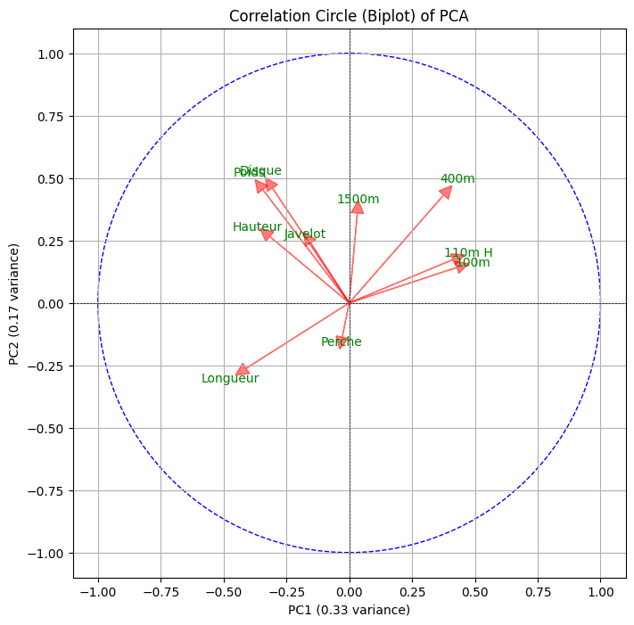

```python
# Create the correlation circle (biplot)
fig, ax = plt.subplots(figsize=(8, 8))

# Plot the correlation circle
for i in range(len(features2)):
    plt.arrow(0, 0, pca.components_[0, i], pca.components_[1, i],
              color='r', alpha=0.5, head_width=0.05, head_length=0.05)
    plt.text(pca.components_[0, i] * 1.15, pca.components_[1, i] * 1.15, features2[i], color='g', ha='center', va='center')

# Add a circle boundary
circle = plt.Circle((0, 0), 1, facecolor='none', edgecolor='b', linestyle='--')
ax.add_artist(circle)

# Label the axes
plt.xlabel(f'PC1 ({explained_variance[0]:.2f} variance)')
plt.ylabel(f'PC2 ({explained_variance[1]:.2f} variance)')
plt.axhline(0, color='black', linewidth=0.5, linestyle='--')
plt.axvline(0, color='black', linewidth=0.5, linestyle='--')
plt.grid()
plt.title('Correlation Circle (Biplot) of PCA')
plt.xlim(-1.1, 1.1)
plt.ylim(-1.1, 1.1)

plt.savefig('Correlation Circle (Biplot) of PCA', dpi= 300)

# Show the plot
plt.show()
```

```python
# 2. Dans une seconde figure, représentez les individus sur un plan factoriel. La taille des bulles représentant les individus doit être liée à la qualité
# de leur représentation.

# 2. In a second figure, represent the individuals on a factorial plane. The size of the bubbles representing the individuals should be related to the quality
# of their representation.
```

```python
# Select only features (numeric values for events) for PCA
features2 = ["100m", "Longueur", "Poids", "Hauteur", "400m", "110m H", "Disque", "Perche", "Javelot", "1500m"]
X = decathlon_df[features2]
```

```python
# Standardizing features (centring and reducing)
scaler = StandardScaler()
X_scaled = scaler.fit_transform(X)

# Perform PCA to reduce dimensionality
pca = PCA(n_components=len(features2))  # Use all components to analyze the variance
X_pca = pca.fit_transform(X_scaled)
```

```python
# Calculating the quality of representation (cos²) for each individual
cos2_2 = (X_pca ** 2).sum(axis=1) / (X_scaled ** 2).sum(axis=1)

# Normalizing the cos² values to scale bubble sizes
cos2_2_normalized = (cos2_2 - cos2_2.min()) / (cos2_2.max() - cos2_2.min())
```

[figure not shown]

```python
# Plotting the factorial plane with bubble sizes proportional to cos²
plt.figure(figsize=(12, 10))
plt.scatter(X_pca[:, 0], X_pca[:, 1], s=(cos2_2_normalized + 0.1) * 500, alpha=0.6, edgecolors='w', linewidth=0.5)

# Adding the athletes' names to the plot
for i, name in enumerate(decathlon_df['Athlete']):
    plt.text(X_pca[i, 0], X_pca[i, 1], name, fontsize=9, ha='right', va='center')

# Adding titles and labels
plt.title('Factorial plane with bubble sizes proportional to quality of representation (cos²)', fontsize=14)
plt.xlabel('PC1', fontsize=12)
plt.ylabel('PC2', fontsize=12)
plt.grid(True)

plt.savefig('Factorial plane with bubble sizes proportional to quality of representation (cos²)', dpi= 300)
plt.show()
```

```python
# 5. Précisez les avantages et inconvénients respectifs des méthodes kmeans et CAH.

# 5. Specify the respective advantages and disadvantages of the kmeans and CAH methods.
```

```python
# K-means and Classification Ascendant Hierarchique (CAH) are two popular unsupervised classification techniques,
# often used to group data into clusters. Here is a comparison of the advantages and disadvantages of each method:


    # 1. k-means


        # Advantages :

            # Simplicity and efficiency: K-means is a simple method to implement and generally quick to run, even on large datasets.

            # Scalability: It works well with large datasets and can be easily extended to handle millions of points.

            # Easy to interpret: K-means results are often easy to interpret, as each point clearly belongs to a single cluster.

            # Suitable for spherical clusters: K-means works well when clusters have a spherical or isotropic shape, i.e.
            # when they are similar in size and shape.


        # Disadvantages :


            # Sensitivity to initial values: K-means results can vary depending on the initial values of the cluster centres.
            # It is often necessary to repeat the algorithm with different initializations.

            # Number of clusters to be defined: K-means requires the number of clusters to be specified in advance, which can be a disadvantage
            # if the optimal number of clusters in the data is not known.

            # Sensitivity to outliers: Outliers or extreme values can distort clusters, as K-means
            # uses the Euclidean distance, which is sensitive to extreme values.

            # Irregularly shaped clusters: It is not suitable for data where clusters have complex or irregular (non-spherical) shapes.


    # 2. Hierarchical Ascending Classification (HAC)


        # Advantages :


            # No need to specify the number of clusters: Unlike K-means, HAC does not require the number of clusters to be defined in advance.
            # It produces a complete hierarchy of clusters (dendrogram) and allows you to choose the number of clusters according to the similarity threshold.

            # Suitable for complex shapes: CAH can identify clusters of various shapes and sizes, making it more flexible than K-means
            # for non-linear data.

            # Intuitive visualisation: The dendrogram generated by HAC makes it easy to visualise the structure of the data and to determine the number
            # of clusters visually.


        # Disadvantages :


            # Computational complexity: HAC is often slower than K-means, especially for large datasets, as it requires computing
            # all distances between points.

            # Limited scalability: It is not well suited to very large datasets, as its complexity increases rapidly with the size of the dataset.
            # of the dataset.

            # Sensitivity to small perturbations: Once a junction is made between clusters, it cannot be modified, which makes the method
            # the method sensitive to small errors in the data or outliers.


# Comparison of Methods


    # Number of clusters:
        # K-Means: Must be specified in advance
        # CAH: Chosen after construction of the dendrogram

    # Cluster shape :
        # K-Means: Spherical
        # CAH: Can be complex in shape

    # Scalability :
        # K-Means: Very scalable for large datasets
        # CAH: Limited scalability, slow for large datasets


    # Robustness to outliers :
        # K-Means: Sensitive
        # CAH: Less robust if outliers influence initial mergers

    # Interpretation :
        # K-Means: Easy to interpret but depends on initialization
        # CAH: Intuitive with dendrogram visualisation

# When should each method be used?


    # K-means is preferable when :
        # You have a large volume of data.
        # You already know how many clusters you want.
        # Clusters have a spherical shape and similar sizes.

    # CAH is preferable when :
        # You don't have a clear idea of the number of clusters.
        # You want to explore the structure of the data.
        # Clusters are complex and non-linear.

# Each method therefore has its advantages and disadvantages depending on the nature of the data and the objectives of the analysis.
```

```python
# 6. Réalisez un clustering par kmeans, puis un par CAH, et représentez les clusters ainsi crées sur le plan factoriel. Une figure par méthode.

# 6. Carry out a clustering by kmeans, then one by CAH, and represent the clusters thus created on the factorial plane. One figure per method.
```

```python
# Select only the features (numeric values for events) for PCA
features2 = decathlon_df[["100m", "Longueur", "Poids", "Hauteur", "400m", "110m H", "Disque", "Perche", "Javelot", "1500m"]]
divers= decathlon_df[["Athlete", "Classement", "Points", "Competition"]]
```

```python
# Standardizing data
scaler= StandardScaler()
scaled_features2= scaler.fit_transform(features2)
```

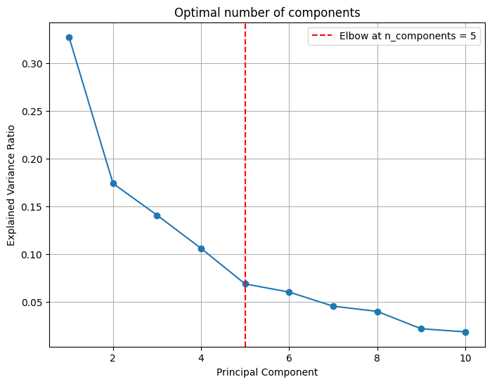

```python
# Plot the scree plot to find number of components
plt.figure(figsize=(8, 6))
plt.plot(range(1, len(pca.explained_variance_ratio_) + 1), pca.explained_variance_ratio_, marker='o')
plt.title('Optimal number of components')
plt.xlabel('Principal Component')
plt.ylabel('Explained Variance Ratio')
plt.grid(True)
plt.axvline(x=5, color='red', linestyle='--', label='Elbow at n_components = 5')
plt.legend()

plt.savefig('Optimal number of components', dpi= 300)
plt.show()
```

```python
# Apply the PCA
pca6= PCA(n_components=5)
scaled_pca6= pca6.fit_transform(scaled_features2)
```

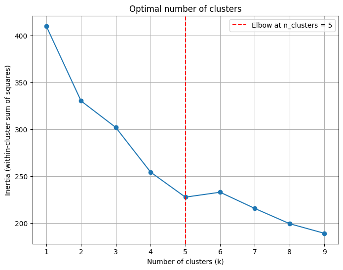

```python
# Scree plot to find the number of clusters

inertia= []

for i in range(1,10):
    kmeans= KMeans(n_clusters= i, random_state= 42)
    kmeans.fit(scaled_features2)
    inertia.append(kmeans.inertia_)

# Plotting the Elbow plot
plt.figure(figsize=(8, 6))
plt.plot(range(1, 10), inertia, marker='o')
plt.title('Optimal number of clusters')
plt.xlabel('Number of clusters (k)')
plt.ylabel('Inertia (within-cluster sum of squares)')
plt.grid(True)
plt.axvline(x=5, color='red', linestyle='--', label='Elbow at n_clusters = 5')
plt.legend()

plt.savefig('Optimal number of clusters', dpi= 300)
plt.show()
```

```python
# Create a k-means clustering model à partir des données précédantes
kmeans_optimal = KMeans(n_clusters=5, init='k-means++', n_init=20)

# Fit the data to the model
kmeans_optimal.fit(scaled_pca6)

# Determine which clusters each data point belongs to:
#  We could also use kmeans.labels_ : It is equivalent to calling the predict() method on the KMeans object after fitting it to the data.
clusters =  kmeans_optimal.predict(scaled_pca6)

# Create a DataFrame for the PCA-transformed data and add the cluster labels
pca_columns = [f'PC{i+1}' for i in range(scaled_pca6.shape[1])]
kmeans_opti = pd.DataFrame(scaled_pca6, columns=pca_columns, index=features2.index)

# Add cluster number to the original data
kmeans_opti['Cluster'] = clusters

kmeans_opti.head()
```

|  | PC1 | PC2 | PC3 | PC4 | PC5 | Cluster |
| --- | --- | --- | --- | --- | --- | --- |
| 0 | -4.038449 | 1.365826 | -0.289957 | 1.941134 | 0.376955 | 0 |
| 1 | -3.919365 | 0.836961 | 0.231175 | 1.493972 | -1.037609 | 0 |
| 2 | -4.619987 | 0.039995 | -0.041586 | -1.313526 | 0.187730 | 0 |
| 3 | -2.233461 | 1.041766 | -1.864362 | -0.743214 | 0.977270 | 1 |
| 4 | -2.168396 | -1.803200 | 0.851017 | -0.284600 | -0.151395 | 3 |

```python
print(kmeans_optimal.cluster_centers_)
```

```
[[-4.19260031  0.74759422 -0.03345566  0.70719352 -0.15764148]
 [-0.58880378 -0.04733801 -1.22864407 -0.43065589 -0.16152049]
 [-0.29861993  0.88626998  2.04816065 -0.76927408  0.00704075]
 [-0.3678799  -1.19428728  0.72189381  0.60632378  0.02789585]
 [ 2.01887843  0.48245487 -0.32035746  0.03323057  0.16129064]]
```

```python
# Add the Athlete column to the features2 dataframe
kmeans_opti['Athlete'] = divers['Athlete']
```

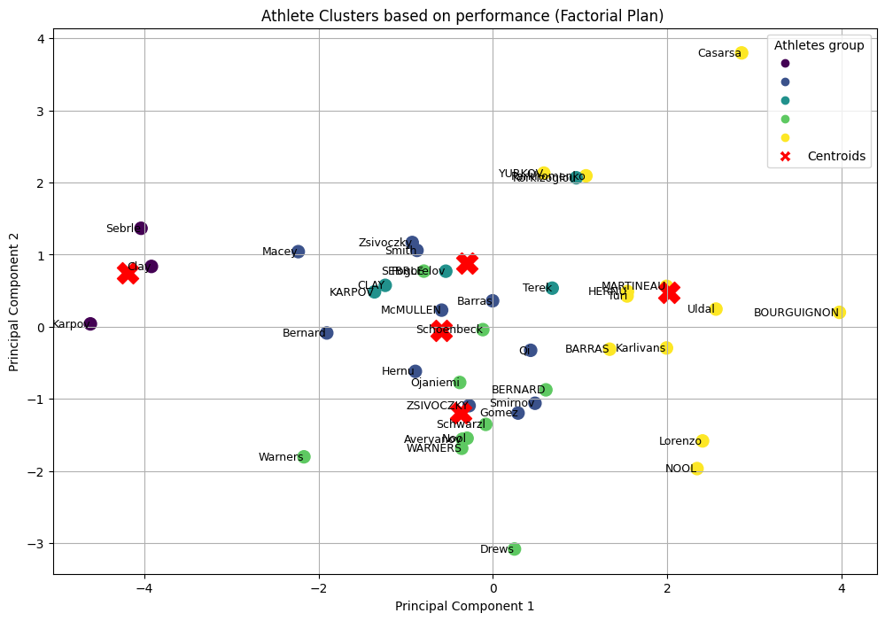

```python
# Plotting the 5 clusters on the factorial plane
plt.figure(figsize=(12, 8))
scatter = plt.scatter(kmeans_opti['PC1'], kmeans_opti['PC2'], c=kmeans_opti['Cluster'], cmap='viridis', s=100)

# Plotting the centroids - this should plot 5 centroids (as per n_clusters=5)
centroids= plt.scatter(kmeans_optimal.cluster_centers_[:, 0], kmeans_optimal.cluster_centers_[:, 1], s=300, c='red', marker='X', label='Centroids')


# Annotating each point with the name of the athlete
for i, name in enumerate(divers['Athlete']):
    plt.text(kmeans_opti['PC1'].iloc[i], kmeans_opti['PC2'].iloc[i], name, fontsize=9, ha='right', va='center')

# Adding labels and legend
plt.title('Athlete Clusters based on performance (Factorial Plan) ')
plt.xlabel('Principal Component 1')
plt.ylabel('Principal Component 2')
handles, labels = scatter.legend_elements()  # Get the graphical markers (handles) and labels from the scatter plot
handles.append(plt.Line2D([0], [0], marker='X', color='w', label='Centroids', markerfacecolor='red', markersize=10))  # Add centroids

plt.legend(handles=handles, title='Athletes group') # Ajouter une légende pour les clusters et les centroids
plt.grid(True)
plt.savefig('Athlete_clusters_based_on_performance_(Factorial_plan).png', dpi=300)
plt.show()
```